# Assignment1

Erik McCullen

Sunday, November 16, 2014

The assignment is broken down into four sections.

First Section - total steps per day

1. What is the total number of steps taken per day and plot?

code for this section:

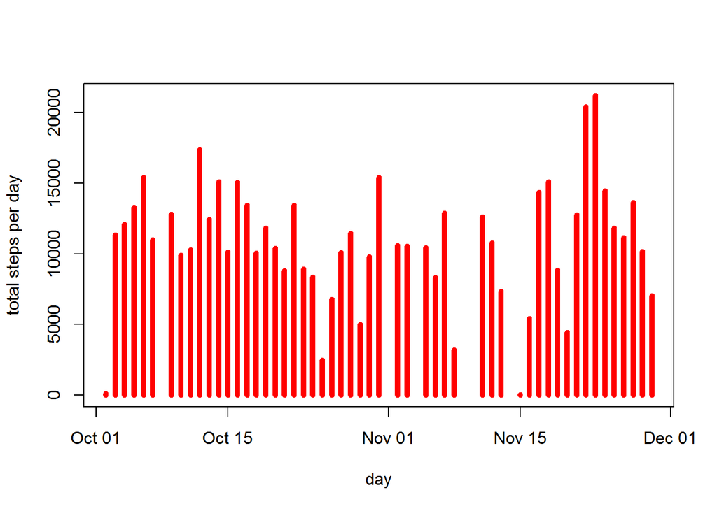

```r
#Erik McCullen
#Reproducible research, assignment 1 code

#load in data, assuming it is in current working directory
alldata<-read.table("activity.csv",sep=",",na.strings="NA",header=TRUE)
cleandata<-na.omit(alldata) #data omitting NA's

#load libraries needed
library(plyr)
library(ggplot2)
library(reshape2)
library(reshape)
library(lubridate)
#Part one--mean total number of steps

#calculate total steps taken per day; omitting days with no steps
#or missing data
p<-melt(cleandata,id=c("date","interval"))
dailysteps<-acast(p,date~variable,sum) #total steps per day
days<-as.Date(row.names(dailysteps)) #days
plot(days,dailysteps,type="h",lwd=5,col="red",ylab="total steps per day",xlab="day")
```

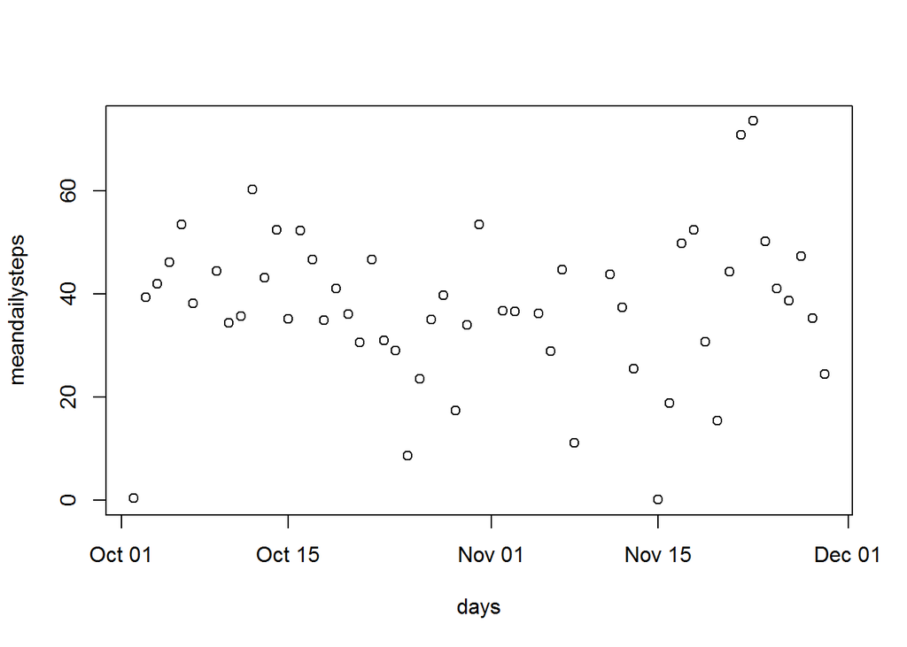

```r
#calculate mean and median daily steps taken
meandailysteps<-acast(p,date~variable,mean)
#meddailysteps<-acast(p,date~variable,median)


plot(days,meandailysteps)
```

Second Section - average daily activity pattern

1. time series plot of the 5 minute intervals

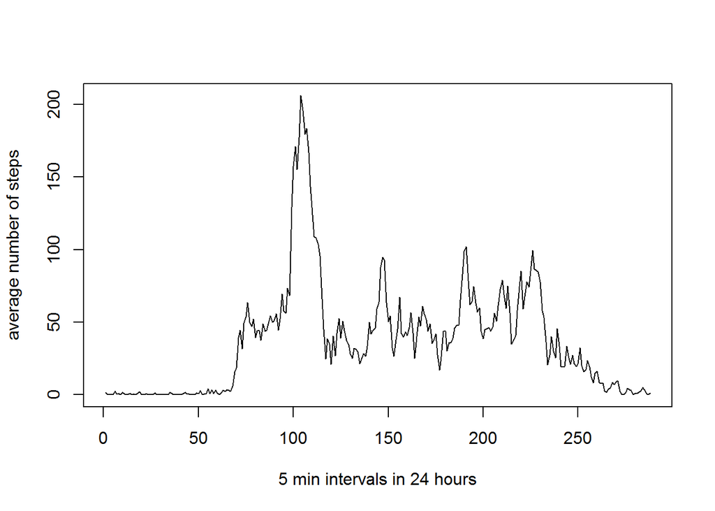

```r
#Part two--average daily activity pattern

#average of the 5-minute intervals across all days
intervalavg<-acast(p,interval~variable,mean)
int<-seq(1:288) # sequence of 5min intervals in 24 hour period
plot(int,intervalavg,type="l",xlab="5 min intervals in 24 hours",ylab="average number of steps")
```

2. maximum 5 minute interval?

```r
maxinterval<-which.max(intervalavg) # index of maximum steps in 5 min intervals
```

The 104th interval is the maximum. This would correspond to 8:40 am

Third Section - inputing missing values

1. Total number of rows with missing data:

```r
#total number of rows with missing data (NA's)
missingdat<-nrow(alldata)-nrow(cleandata)
```

The total number of missing rows is 2304

2 & 3. Strategy for missing values? I decided to replace the missing values with the equivalent 5 minute interval average calculated above. Te code to create the new dataset with these missing values is:

```r
newdata<-alldata

#replacing NA's with the equivalent 5 min interval average across all
#days, intervalavg

for(i in 0:60){

        for(j in 1:288){
                if (is.na(alldata$steps[j+(288*i)])==TRUE) {
                        newdata$steps[j+(288*i)]<-intervalavg[j]}
                else{}
        }
}
```

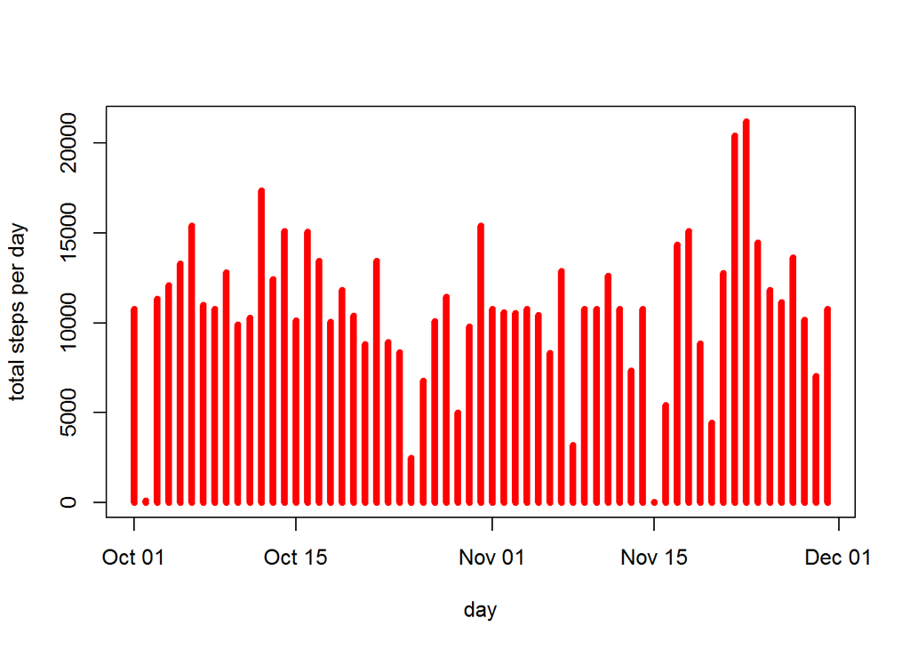

```r
#now calculate total daily steps, and mean as in first part, but using
#newdata that has had the NA's replaced

#calculate total steps taken per day; omitting days with no steps
#or missing data
p2<-melt(newdata,id=c("date","interval"))
dailystepsnew<-acast(p2,date~variable,sum) #total steps per day
days<-as.Date(row.names(dailystepsnew)) #days
plot(days,dailystepsnew,type="h",lwd=5,col="red",ylab="total steps per day",xlab="day")
```

```r
#calculate mean and median daily steps taken of this new data
meandailystepsnew<-acast(p2,date~variable,mean)
meddailystepsnew<-acast(p2,date~variable,median)
```

Fourth Section - weekday vs. weekend activity patterns

1 & 2. The code to examine the difference in activity patterns between the weekday and weekend is given below:

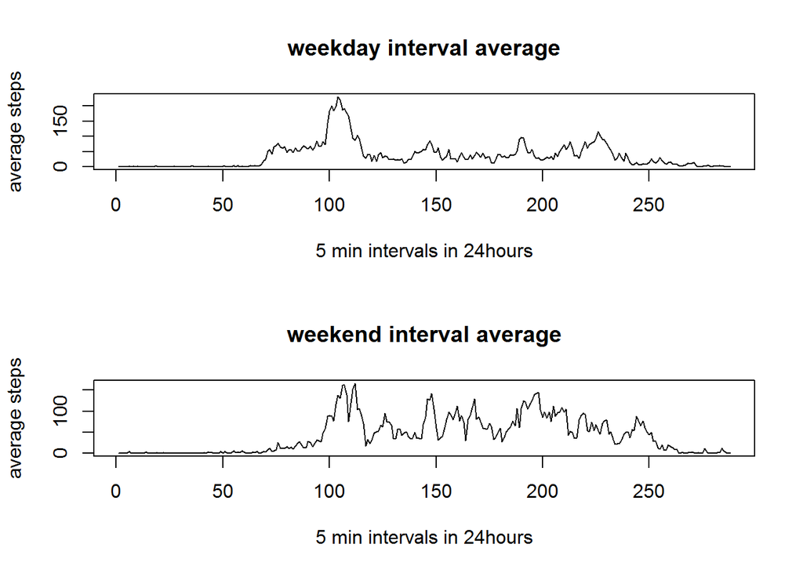

```r
#last section: weekday/weekend differences
days<-as.Date(newdata$date)
day<-wday(days)

#using for loop to set weekdays and weekends
for(i in 1:nrow(newdata)){
        if(day[i]==1 | day[i]==7){day[i]<-c("weekend")}
                else {day[i]<-c("weekday")}
}
newdata<-cbind(newdata,day)

#subset all the data into weekend and weekday
pwend<-newdata[newdata$day=="weekend",]
pwday<-newdata[newdata$day=="weekday",]

#now get average of 5 min intervals
pwend2<-melt(pwend,id=c("date","interval","day"))
pwday2<-melt(pwday,id=c("date","interval","day"))

intervalavgwend<-acast(pwend2,interval~variable,mean)
intervalavgwday<-acast(pwday2,interval~variable,mean)

par(mfrow=c(2,1))
plot(int,intervalavgwday,type="l",xlab="5 min intervals in 24hours",ylab="average steps",main="weekday interval average")
plot(int,intervalavgwend,type="l",xlab="5 min intervals in 24hours",ylab="average steps",main="weekend interval average")
```